# Generador de ONTs - Guía de usuario

## Descripción

Este programa te ayuda a configurar las ONTs (modems) de manera sencilla y automática. Utiliza una interfaz de línea de comandos (CLI) en la que solo necesitas decir qué modelo de modem tenes. Funciona con los siguientes modelos:

- Askey 8115
- Askey 3505
- Mitrastar 2541
- Mitrastar 2741
- ZTE

## Inicio

Después de haber instalado el programa, lo encontrarás en tu escritorio y estará listo para que lo uses.

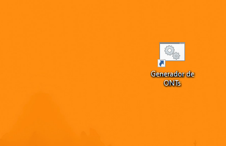

> *Acceso directo al Generador de ONTs*

Cuando abras el programa, te vas a encontrar con la siguiente ventana, donde el programa te va a hacer una serie de preguntas para empezar el proceso.

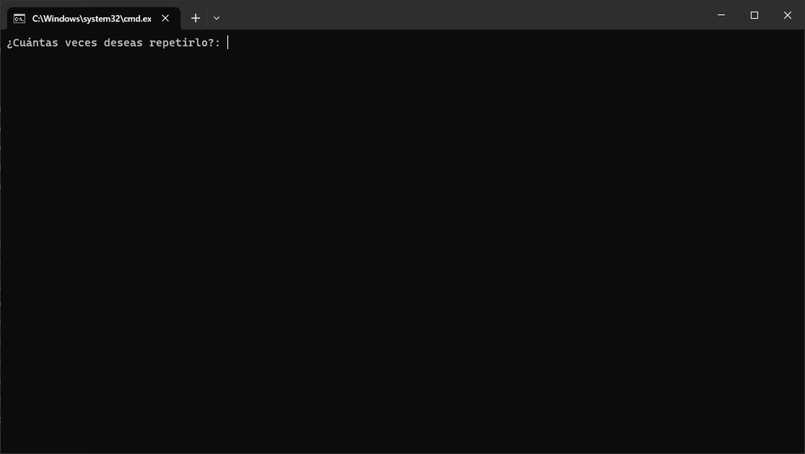

> Puede parecer un poco extraña y complicada al principio, ¡pero en realidad es fácil de usar!

## Primeros pasos

Lo primero que tenés que saber sobre este programa es que utiliza las hojas de Google Sheets. Es decir, para poder utilizarlo, necesitás tener uno o varios registros de modems en ese servicio.

Sin embargo, para que el programa pueda obtener y escribir datos desde estos registros, es necesario seguir una serie de pasos. Es importante aclarar que estos pasos se realizan solo una vez por cada registro.

$$\large{\text{Importante aclaración: estos pasos se realizan una única
vez por registro}}$$

1. El primer paso que tenés que hacer es ingresar al registro que desees que aparezca en el programa y compartirlo a este usuario

> pythongsapi@storied-port-306513.iam.gserviceaccount.com

> Botón de compartir archivo

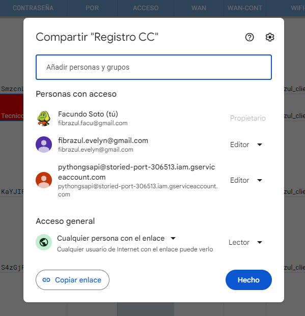

> Pega en “Añadir personas y grupos” el email anterior

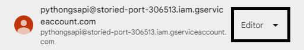

> Asegurate de darle permisos de “Editor” y luego clickea en “Hecho”
2. Luego de esto copiar el ID del mismo desde la URL

[figure not shown]

> Ejemplo de URL

Como se muestra en la imagen, el ID de tu registro es esa cadena de letras y números que se encuentra separada por “/”.

[figure not shown]

> El texto dentro del rectángulo es la ID del registro

La ID tiene las siguientes características:

- Es una cadena de caracteres alfanuméricos.
- Es única para cada hoja de Google Sheets.
- Suele ser larga y está compuesta por letras mayúsculas, letras minúsculas, números y símbolos.
- Se encuentra en la URL de la hoja de Google Sheets después de “/d/”.
1. Una vez que tengas esta ID, ingresa al programa y escribe “administrar” y luego presiona Enter

[figure not shown]

Luego de haber hecho esto te va a preguntar el nombre del registro que querés agregar

[figure not shown]

> Para este ejemplo el registro se llamará “ff”. El nombre del registro puede contener letras o números, pero en un máximo total de 5 caracteres.

Ahora el programa te va a pedir el ID del registro que obtuviste previamente, solo resta pegarlo y presionar “Enter”

[figure not shown]

> Una vez terminado el programa se va a reiniciar y ya podrás usarlo

## Las preguntas

El programa te va a hacer una serie de preguntas que tenés que responder escribiendo, y cuando hayas contestado todo, va a empezar a configurar las ONTs de acuerdo a lo que especificaste.

1. La primera pregunta va a ser: “¿Cuántas veces deseas repetirlo?”, esto se refiere a cuántos modems deseas configurar.

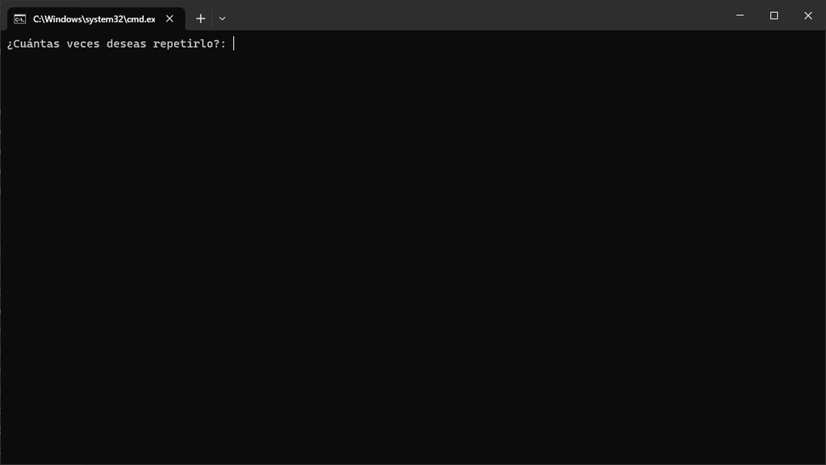

> ¡Recordá que solo acepta valores numéricos positivos! Así que si intentás escribir letras o números negativos, no va a funcionar. ¡No te pases de listo intentando engañar al programa! 😉
2. Después de haber ingresado la cantidad de veces que querés repetir el proceso, el programa te va a pedir que declares los modelos de ONT. Para hacerlo, simplemente escribí el número correspondiente al modelo y apretá “Enter” para declararlo. Por ejemplo, si querés configurar un modelo Askey 8115, solo tenés que escribir “1” y después apretar “Enter”. El programa va a entender tu elección y va a empezar a configurar según el modelo que declaraste. ¡Así de fácil!

$$1) // 8115 = 1 // 3505 = 2 // 2541 = 3 // 2741 = 4 // ZTE = 5$$

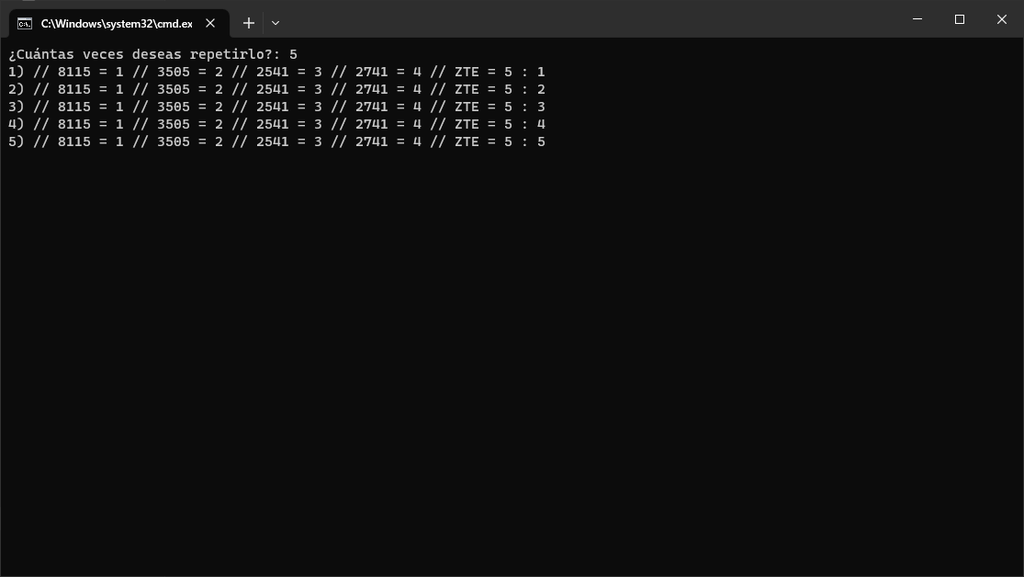

> En este ejemplo, el usuario decidió repetir el proceso cinco veces y declaró los modelos de ONT usando los números asignados a esos modelos.
3. Ahora, el programa te va a preguntar en qué registro deseas trabajar, es decir, qué documento de Google Sheets quieres utilizar para acceder a las contraseñas de fábrica de los modems. Como se indica en la sección de Primeros pasos, esto significa que debes escribir las contraseñas en un archivo de Google Sheets para que el programa pueda leerlas y usarlas durante el proceso de configuración.

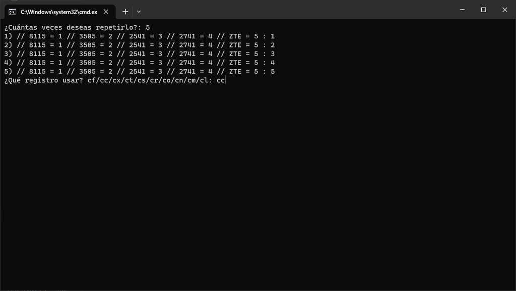

> En este ejemplo, se muestran registros distintos a los que normalmente utilizarías. Son solo a modo de ejemplo.
4. Ahora, el programa te va a preguntar: “¿Cuál es el número del módem inicial?”. Esto es para que el programa sepa con qué número configurar cada modem. Por ejemplo, si querés configurar el modem número 500 de este registro, solo tenés que escribir “500” y apretar Enter. El programa configurará ese modem como 500, y automáticamente los siguientes dispositivos en la secuencia se configurarán como 501, 502, 503, y así sucesivamente.

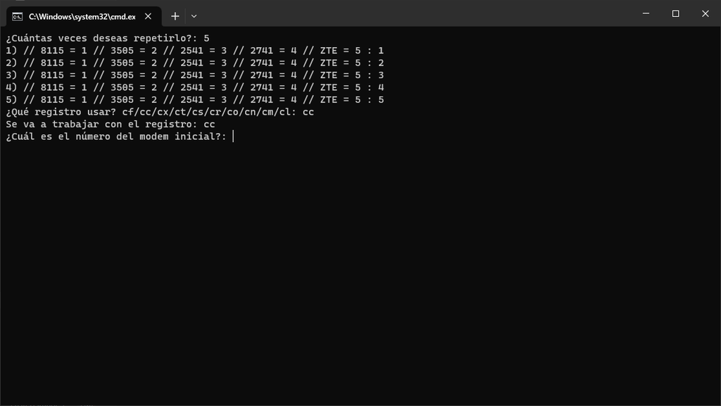

> ¡Muy fácil de entender! 😄
5. Una vez que hayas presionado Enter, comenzará el proceso de configuración de los módems. Como indica el programa, se buscarán las contraseñas de fábrica en el registro de Google Sheets que hayas seleccionado, y con esas contraseñas se llevará a cabo la configuración.

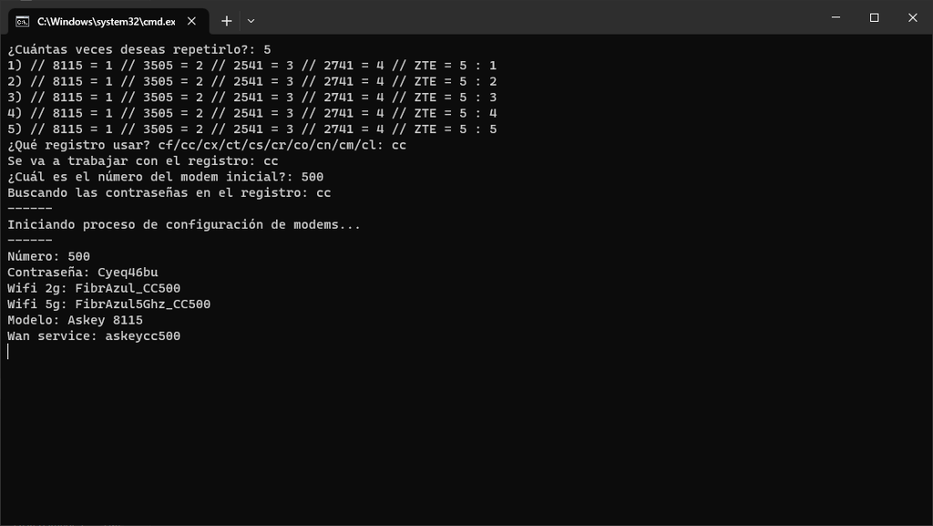

> Como podés notar al final de esta imagen, se exhiben los datos del módem a configurar, incluyendo la contraseña de fábrica obtenida desde Google Sheets, el modelo y los valores que se van a emplear, tales como el nombre de la red Wi-Fi y el servicio de WAN.
6. Una vez que comience el proceso, vas a ver cómo se abre una ventana de Google Chrome donde se realiza la configuración de forma rápida. En la ventana del programa, aparecerán mensajes que te indicarán en qué parte del proceso se encuentra. Después de completar cada configuración, el programa te pedirá que aprietes Enter para avanzar al siguiente módem. Es fundamental que antes de darle a Enter, hayas cambiado el cable de red al próximo módem en la línea. ¡No te olvides de este paso importante!

[figure not shown]

> En esta imagen, podés apreciar los mensajes que el programa va mostrando en cada etapa del proceso. Además, verás el mensaje de “Proceso completado” que te pedirá presionar Enter; hasta que no lo hagas, no avanzará con las configuraciones. ¡No te olvides de darle a Enter para seguir adelante!
7. Y eso sería todo. Si tenemos la suerte de que todos los modems funcionen correctamente, llegarás al final del proceso de configuración y el programa habrá terminado su tarea con éxito. ¡Felicitaciones por completar la configuración! 😄